# MATH250 Final Project - The Weeknd

Author

Sergei Vorobev

```r
library(tidyverse)
library(here)
library(gt)
library(ggrepel) # library to shift overlapping plot labels
library(viridis) # Dark2 doesn't have enough colors for all the tracks on an album

path <- here("Data", "the_weeknd.csv")
the_weeknd <- read_csv(path)
```

## Introduction

*The Weeknd* is a Canadian singer who initially gained fame by posting his mix tapes online. He has since become a critically acclaimed musician and Grammy Award winner.[^1] I was introduced to *The Weekend* through his song *The Hills* in middle school, but since I’ve fallen in love with the magical, somber sound of albums *Kiss Land* and *After Hours*.

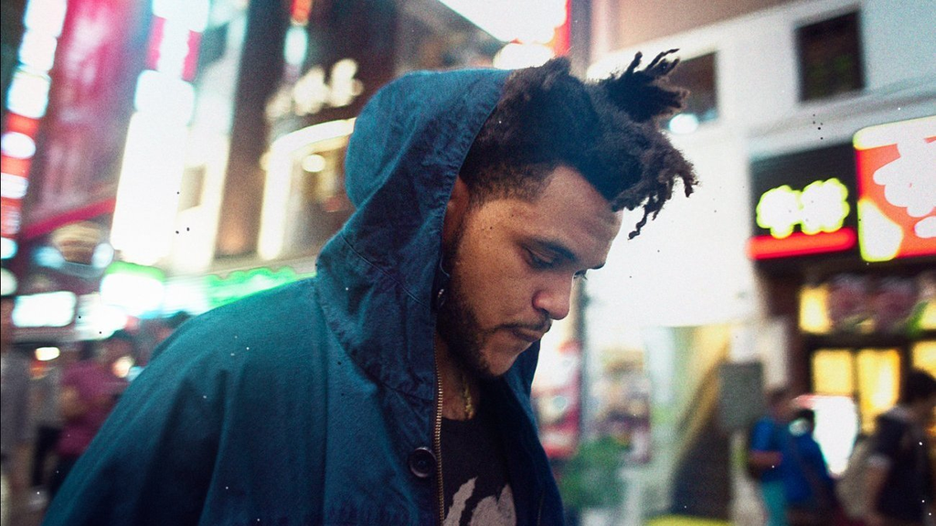

Abel Makkonen Tesfaye - The Weeknd

Fans, such as myself, often see *Kiss Land* as a precursor to *After Hours* due to their shared dark, cinematic R&B sound, while critics regard *After Hours* as a more polished, superior work.[^2]

Differences in opinion and my personal perception motivate me to determine whether the two albums are similar. I aim to test whether the mean `energy`, which reflects dynamics, loudness, and intensity, is the same between the two albums:

- Null hypothesis: The mean energy levels of *Kiss Land* and *After Hours* are equal.
- Alternative hypothesis: The mean energy levels of *Kiss Land* and *After Hours* are different.

I also want to conduct exploratory analysis on the following key attributes:

- `danceability`: reflecting the suitability for dancing, a key factor in pop.
- `valence`: a measure of how positive a track sounds, reflecting the prominence of melancholy in his music.

## Energy analysis

```r
albums <- c("Trilogy",
            "Kiss Land",
            "Beauty Behind The Madness",
            "Starboy",
            "My Dear Melancholy,",
            "After Hours",
            "Dawn FM")

the_weeknd_sm <- the_weeknd %>%
  select(album_name, track_name, energy, danceability, valence) %>%
  filter(album_name %in% albums) %>%
  mutate(album_name = factor(album_name, levels = albums))

main_albums <- the_weeknd_sm %>%
  filter(album_name %in% c("Kiss Land", "After Hours"))

after_hours <- the_weeknd_sm %>%
  filter(album_name == "After Hours")
```

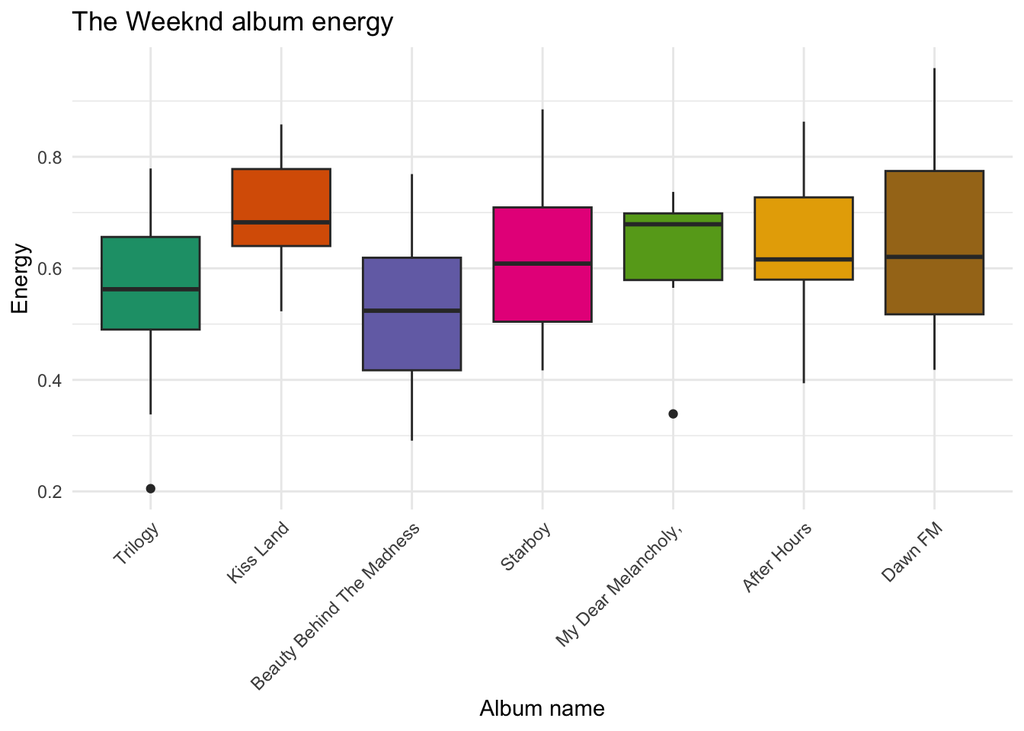

```r
ggplot(the_weeknd_sm,
       aes(x = album_name,
           y = energy,
           fill = album_name)) +
  geom_boxplot(show.legend = FALSE) +
  scale_fill_brewer(palette = "Dark2") +
  theme_minimal() +
  theme(axis.text.x = element_text(angle = 45, hjust = 1)) + #https://www.geeksforgeeks.org/rotating-and-spacing-axis-labels-in-ggplot2-in-r/
  labs(title = "The Weeknd album energy",
       x = "Album name",
       y = "Energy")
```

The boxplots show a slight trend of increasing `energy` with each album release, but *Kiss Land* deviates, presenting the highest median `energy`. This aligns with *The Weeknd*’s view of the album as his most honest and vulnerable.[^3] Median-wise, *Kiss Land* is closer to *My Dear Melancholy,* than *After Hours*, supporting critics who suggest that tracks from *My Dear Melancholy,* could fit well into *Kiss Land* without disrupting its style.[^4] To compare the means between the albums of focus, a **two-sample t-test** is required.

[figure not shown]

Kiss Land album cover

```r
t.test(energy ~ album_name, data = main_albums)
```

```
    Welch Two Sample t-test

data:  energy by album_name
t = 1.3068, df = 21.349, p-value = 0.2052
alternative hypothesis: true difference in means between group Kiss Land and group After Hours is not equal to 0
95 percent confidence interval:
 -0.03699622  0.16245336
sample estimates:
  mean in group Kiss Land mean in group After Hours
                0.7033000                 0.6405714
```

After conducting the test, it resulted in a p-value of **0.2052**. Such a high p-value indicates no significant difference in energy levels between *Kiss Land* and *After Hours*. We fail to reject the null and draw no further conclusions.

## Valence and danceability analysis

```r
the_weeknd_summary <- the_weeknd_sm %>%
  group_by(album_name) %>%
  summarise("Average energy" = round(mean(energy), 3),
          "Average valence" = round(mean(valence), 3),
          "Average danceability" = round(mean(danceability), 3)) %>%
  rename("Album name" = album_name)
gt(the_weeknd_summary)
```

| Album name | Average energy | Average valence | Average danceability |
| --- | --- | --- | --- |
| Trilogy | 0.554 | 0.287 | 0.556 |
| Kiss Land | 0.703 | 0.297 | 0.563 |
| Beauty Behind The Madness | 0.520 | 0.298 | 0.563 |
| Starboy | 0.614 | 0.469 | 0.646 |
| My Dear Melancholy, | 0.616 | 0.275 | 0.445 |
| After Hours | 0.641 | 0.251 | 0.508 |
| Dawn FM | 0.655 | 0.463 | 0.590 |

On average *After Hours* appears lower in all three attributes, and the most similar to *Kiss Land*. *My Dear Melancholy,* does not appear to be as similar as *After Hours*.

[figure not shown]

After Hours album cover

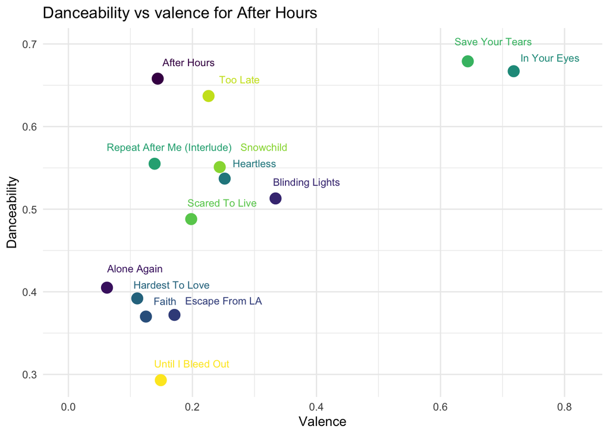

```r
ggplot(after_hours,
       aes(x = valence,
           y = danceability,
           color = track_name,
           label = track_name)) +
  geom_point(show.legend = FALSE,
             size = 4) +
  geom_text_repel(size = 3,
                  nudge_x = 0.05,
                  nudge_y = 0.02,
                  segment.color = NA) + #https://rdrr.io/cran/ggrepel/man/geom_text_repel.html
  scale_color_viridis(discrete = TRUE) + # Dark2 doesn't have enough colors
  theme_minimal() +
  labs(title = "Danceability vs valence for After Hours",
       x = "Valence",
       y = "Danceability") +
  theme(legend.position = "none") +
  scale_x_continuous(limits = c(0, 0.82)) #https://ggplot2.tidyverse.org/reference/scale_continuous.html
```

In *After Hours*, `danceability` is higher in happier, upbeat tracks. For example, *Save Your Tears* has a groovy baseline and fast tempo, increasing both `danceability` and `valence`, while *Until I Bleed Out* is slower with dragged vocals, lowering both values.

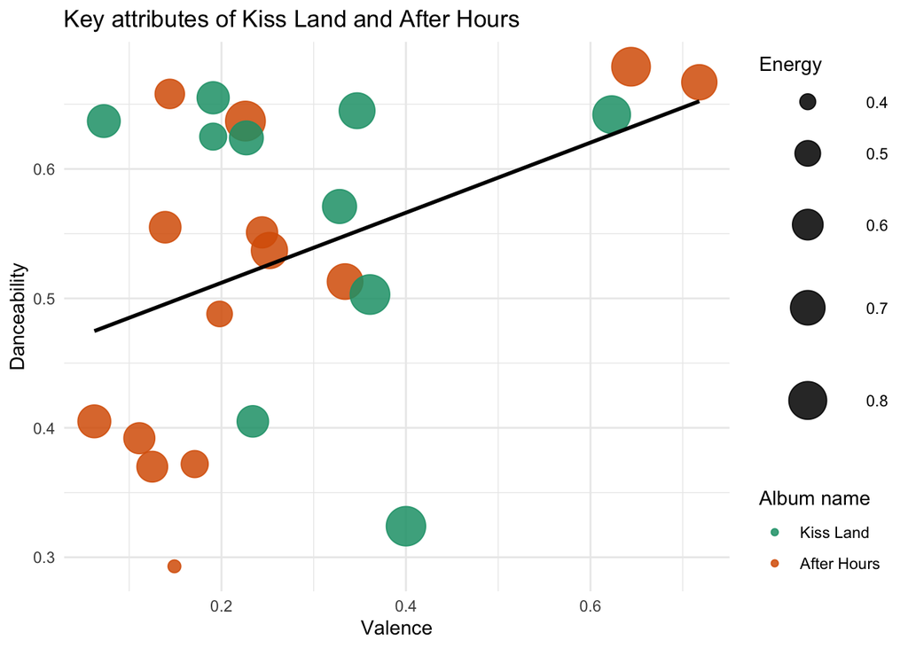

```r
ggplot(main_albums,
       aes(x = valence,
           y = danceability,
           color = album_name,
           size = energy)) +
  geom_point(alpha = 0.85) +
  geom_smooth(method = "lm", se = FALSE, color = "black") +
  scale_color_brewer(palette = "Dark2") +
  theme_minimal() +
  labs(title = "Key attributes of Kiss Land and After Hours",
       x = "Valence",
       y = "Danceability",
       color = "Album name",
       size = "Energy") +
  scale_size_continuous(range = c(3, 10)) +
  guides(size = guide_legend(override.aes = list(linetype = 0))) #https://aosmith.rbind.io/2020/07/09/ggplot2-override-aes/
```

```r
the_weeknd_danceability <- main_albums %>%
  group_by(album_name) %>%
  summarise("Least danceable song" = track_name[which.min(danceability)],
            "Least danceable energy" = energy[which.min(danceability)],
            "Most danceable song" = track_name[which.max(danceability)],
            "Most danceable energy" = energy[which.max(danceability)]) %>%
  rename("Album name" = album_name)
gt(the_weeknd_danceability)
```

| Album name | Least danceable song | Least danceable energy | Most danceable song | Most danceable energy |
| --- | --- | --- | --- | --- |
| Kiss Land | Kiss Land | 0.852 | Tears In The Rain | 0.636 |
| After Hours | Until I Bleed Out | 0.394 | Save Your Tears | 0.825 |

## Conclusion

The analysis suggests *Kiss Land* and *After Hours* are similar in key attributes. Both albums likely have similar `energy` on average. While `valence` and `danceability` also appear similar, their distributions differ. Further exploration of how `valence` affects `danceability` in *The Weeknd*’s music would be valuable.

## Footnotes

[^1]: Bauer, Patricia. “The Weeknd | Biography, Songs, Albums, & Facts.” Encyclopedia Britannica, December 3, 2024. https://www.britannica.com/biography/the-Weeknd.
[^2]: Herrera, Isabelia. “The Weeknd: After Hours.” Pitchfork, March 24, 2020. https://pitchfork.com/reviews/albums/the-weeknd-after-hours/.
[^3]: Mench, Chris. “The Weeknd on the Failure of ‘Kiss Land’: ‘I Was Definitely Emotionally Tapped Out.’” Genius, August 2, 2021. https://genius.com/a/the-weeknd-on-the-failure-of-kiss-land-i-was-definitely-emotionally-tapped-out.
[^4]: Luzaityte, Rebeka. “In Defence of Kiss Land - Rebeka Luzaityte - Medium.” Medium, December 8, 2021. https://medium.com/@rebekalztt/in-defence-of-kiss-land-d472ed155d73.